# Linear Regression Model

| Model Fit Measures Model | Model Fit Measures R | Model Fit Measures R² | Model Fit Measures Adjusted R² | Model Fit Measures AIC | Model Fit Measures BIC | Model Fit Measures RMSE | Model Fit Measures Overall Model Test F | Model Fit Measures Overall Model Test df1 | Model Fit Measures Overall Model Test df2 | Model Fit Measures Overall Model Test p |
| --- | --- | --- | --- | --- | --- | --- | --- | --- | --- | --- |
| 1 | 0.884 | 0.781 | 0.753 | 76.0 | 76.9 | 8.03 | 28.5 | 1 | 8 | <.001 |

Note. Models estimated using sample size of N=10

| Model Coefficients - Participants Predictor | Model Coefficients - Participants Estimate | Model Coefficients - Participants SE | Model Coefficients - Participants t | Model Coefficients - Participants p |
| --- | --- | --- | --- | --- |
| Intercept | 61.09 | 4.866 | 12.55 | <.001 |
| t | -1.10 | 0.207 | -5.34 | <.001 |

## Assumption Checks

| Normality Tests | Normality Tests Statistic | Normality Tests p |
| --- | --- | --- |
| Shapiro-Wilk | 0.868 | .096 |
| Kolmogorov-Smirnov | 0.221 | .638 |
| Anderson-Darling | 0.622 | .075 |

Note. Additional results provided by *moretests*

| Heteroskedasticity Tests | Heteroskedasticity Tests Statistic | Heteroskedasticity Tests p |
| --- | --- | --- |
| Breusch-Pagan | 0.771 | .380 |
| Goldfeld-Quandt | 0.913 | .529 |
| Harrison-McCabe | 0.685 | .809 |

Note. Additional results provided by *moretests*

| Durbin–Watson Test for Autocorrelation Autocorrelation | Durbin–Watson Test for Autocorrelation DW Statistic | Durbin–Watson Test for Autocorrelation p |
| --- | --- | --- |
| 0.372 | 0.762 | .002 |

[3]

| Collinearity Statistics | Collinearity Statistics VIF | Collinearity Statistics Tolerance |
| --- | --- | --- |
| t | 1.00 | 1.00 |

[3]

### Q-Q Plot

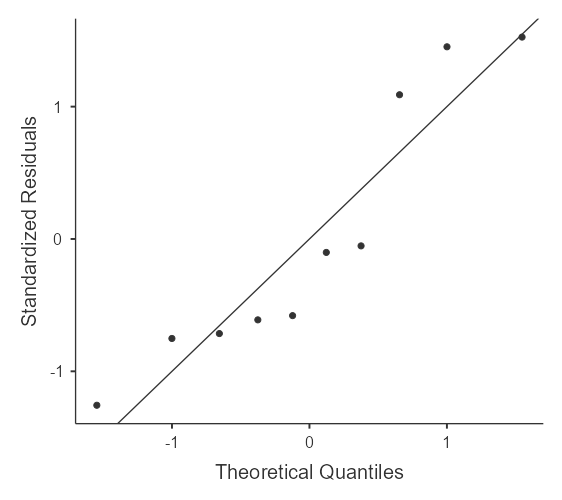

### Residuals Plots

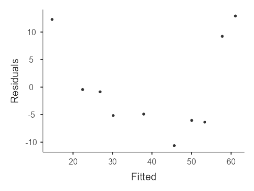

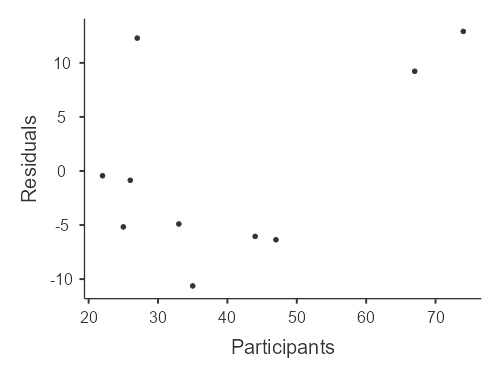

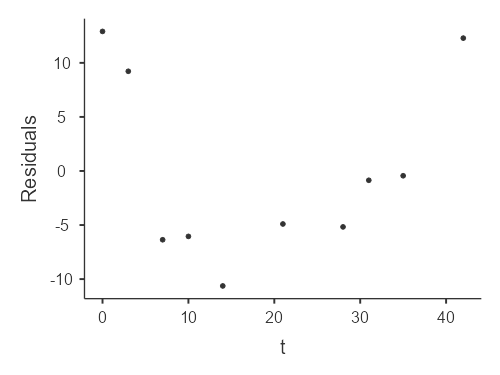

# Log-transformed Regression Model

| Model Fit Measures Model | Model Fit Measures R | Model Fit Measures R² | Model Fit Measures Adjusted R² | Model Fit Measures AIC | Model Fit Measures BIC | Model Fit Measures RMSE | Model Fit Measures Overall Model Test F | Model Fit Measures Overall Model Test df1 | Model Fit Measures Overall Model Test df2 | Model Fit Measures Overall Model Test p |
| --- | --- | --- | --- | --- | --- | --- | --- | --- | --- | --- |
| 1 | 0.923 | 0.852 | 0.833 | -3.14 | -2.23 | 0.153 | 46.0 | 1 | 8 | <.001 |

Note. Models estimated using sample size of N=10

| Model Coefficients - ln_Participants Predictor | Model Coefficients - ln_Participants Estimate | Model Coefficients - ln_Participants SE | Model Coefficients - ln_Participants t | Model Coefficients - ln_Participants p |
| --- | --- | --- | --- | --- |
| Intercept | 4.1174 | 0.09289 | 44.32 | <.001 |
| t | -0.0268 | 0.00395 | -6.78 | <.001 |

## Assumption Checks

| Normality Tests | Normality Tests Statistic | Normality Tests p |
| --- | --- | --- |
| Shapiro-Wilk | 0.874 | .112 |
| Kolmogorov-Smirnov | 0.271 | .383 |
| Anderson-Darling | 0.644 | .065 |

Note. Additional results provided by *moretests*

| Heteroskedasticity Tests | Heteroskedasticity Tests Statistic | Heteroskedasticity Tests p |
| --- | --- | --- |
| Breusch-Pagan | 0.835 | .361 |
| Goldfeld-Quandt | 6.06 | .087 |
| Harrison-McCabe | 0.462 | .435 |

Note. Additional results provided by *moretests*

| Durbin–Watson Test for Autocorrelation Autocorrelation | Durbin–Watson Test for Autocorrelation DW Statistic | Durbin–Watson Test for Autocorrelation p |
| --- | --- | --- |
| 0.149 | 1.16 | .066 |

[3]

| Collinearity Statistics | Collinearity Statistics VIF | Collinearity Statistics Tolerance |
| --- | --- | --- |
| t | 1.00 | 1.00 |

[3]

### Q-Q Plot

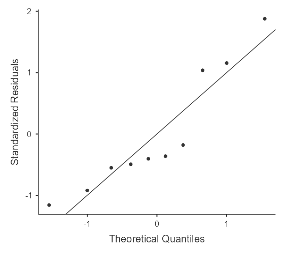

### Residuals Plots

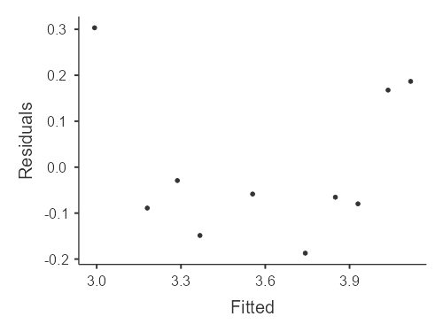

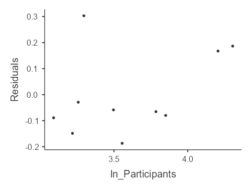

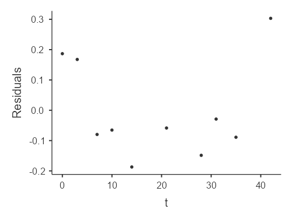

# Flexplot: Linear model

## Analysis Plot

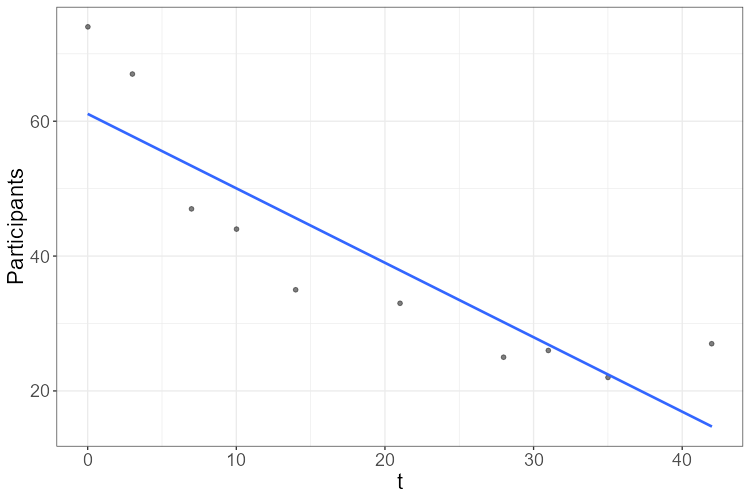

# Flexplot: Log-transformed model

## Analysis Plot

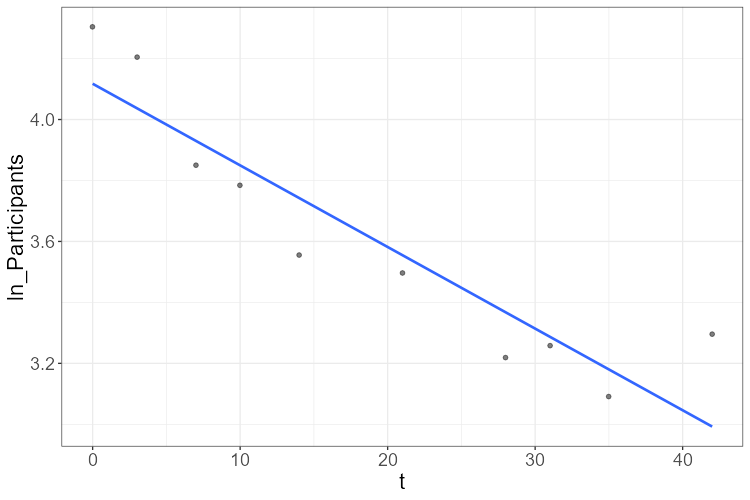

Data Quality Alerts:

- Note: Unequal time intervals detected. Trend interpretation should account for irregular spacing.

##### Analysis Summary

**Dataset:** 10 observations across 10 time points

**Participants** ranges from 22.0 to 74.0 (mean: 40.0, SD: 18.1)

**Trend:** very strong decreasing trend detected (R² = 0.781)

| Data Summary Statistic | Data Summary Value |
| --- | --- |
| Number of Observations | 10 |
| Number of X-axis Points | 10 |
| Number of Groups | 1 |
| Y Mean | 40.0 |
| Y Median | 34.0 |
| Y Standard Deviation | 18.1 |
| Y Range | 22.0 - 74.0 |

[output not shown]

##### Statistical Assumptions & Guidelines

Understanding the assumptions behind your analysis helps ensure valid interpretation.

**Line Chart Assumptions**

- **Continuous Y-variable:** The outcome variable should be numeric and measurable.
- **Ordered X-variable:** Time points or sequence should have meaningful order.
- **Independence:** Observations should be independent unless using appropriate methods for correlated data.

**Trend Analysis Assumptions**Key Assumptions:

- **Linearity:** The relationship between variables is approximately linear.
- **Independence:** Data points are independent of each other.
- **Normality:** Residuals are approximately normally distributed.
- **Homoscedasticity:** Variance of residuals is constant across fitted values.

Assumption Checks:

- Potential non-linear relationship detected. Consider polynomial or spline fitting.
- Residuals appear normally distributed (Shapiro-Wilk p > 0.05).

**Clinical Interpretation Guidelines**Effect Size Interpretation:

- **R² ≥ 0.50:** Large effect - clinically significant relationship
- **R² = 0.25-0.49:** Medium effect - moderate clinical relevance
- **R² = 0.10-0.24:** Small effect - limited clinical significance
- **R² < 0.10:** Very small effect - minimal clinical importance

Confidence Intervals:

When displayed, confidence intervals show the uncertainty around trend lines. Wider intervals indicate greater uncertainty.

Sample Size Considerations:

Minimum recommendations: 10+ observations for basic trends, 30+ for reliable confidence intervals, 50+ for robust correlation analysis.

## Line Chart: Participants by t

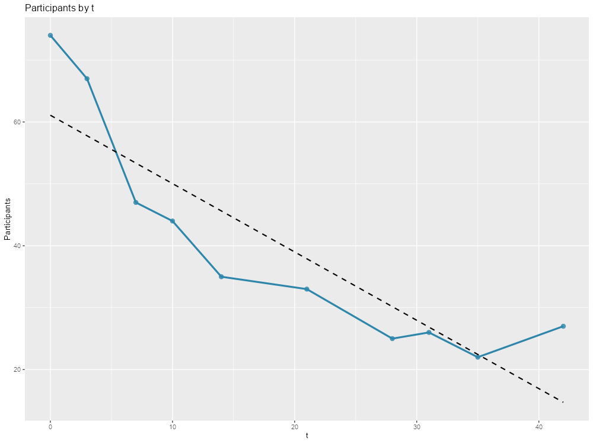

[4]

Data Quality Alerts:

- Note: Unequal time intervals detected. Trend interpretation should account for irregular spacing.

##### Analysis Summary

**Dataset:** 10 observations across 10 time points

**ln_Participants** ranges from 3.09 to 4.30 (mean: 3.61, SD: 0.420)

**Trend:** very strong decreasing trend detected (R² = 0.852)

| Data Summary Statistic | Data Summary Value |
| --- | --- |
| Number of Observations | 10 |
| Number of X-axis Points | 10 |
| Number of Groups | 1 |
| Y Mean | 3.61 |
| Y Median | 3.53 |
| Y Standard Deviation | 0.420 |
| Y Range | 3.09 - 4.30 |

[output not shown]

##### Statistical Assumptions & Guidelines

Understanding the assumptions behind your analysis helps ensure valid interpretation.

**Line Chart Assumptions**

- **Continuous Y-variable:** The outcome variable should be numeric and measurable.
- **Ordered X-variable:** Time points or sequence should have meaningful order.
- **Independence:** Observations should be independent unless using appropriate methods for correlated data.

**Trend Analysis Assumptions**Key Assumptions:

- **Linearity:** The relationship between variables is approximately linear.
- **Independence:** Data points are independent of each other.
- **Normality:** Residuals are approximately normally distributed.
- **Homoscedasticity:** Variance of residuals is constant across fitted values.

Assumption Checks:

- Potential non-linear relationship detected. Consider polynomial or spline fitting.
- Residuals appear normally distributed (Shapiro-Wilk p > 0.05).

**Clinical Interpretation Guidelines**Effect Size Interpretation:

- **R² ≥ 0.50:** Large effect - clinically significant relationship
- **R² = 0.25-0.49:** Medium effect - moderate clinical relevance
- **R² = 0.10-0.24:** Small effect - limited clinical significance
- **R² < 0.10:** Very small effect - minimal clinical importance

Confidence Intervals:

When displayed, confidence intervals show the uncertainty around trend lines. Wider intervals indicate greater uncertainty.

Sample Size Considerations:

Minimum recommendations: 10+ observations for basic trends, 30+ for reliable confidence intervals, 50+ for robust correlation analysis.

## Line Chart: ln_Participants by t

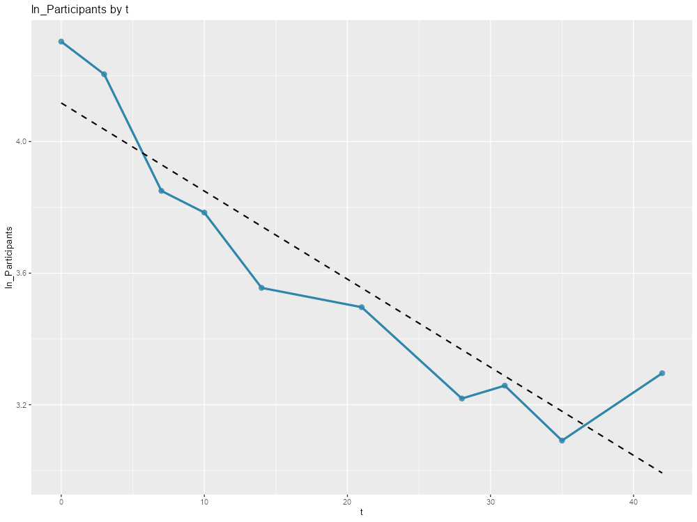

[4]

# References

[1] The jamovi project (2025). *jamovi*. (Version 2.7) [Computer Software]. Retrieved from https://www.jamovi.org.

[2] R Core Team (2025). *R: A Language and environment for statistical computing*. (Version 4.5) [Computer software]. Retrieved from https://cran.r-project.org. (R packages retrieved from CRAN snapshot 2025-05-25).

[3] Fox, J., & Weisberg, S. (2024). *car: Companion to Applied Regression*. [R package]. Retrieved from https://cran.r-project.org/package=car.

[4] Serdar Balci (2022). *ClinicoPath jamovi Module doi:10.5281/zenodo.3997188*. [R package]. Retrieved from https://github.com/sbalci/ClinicoPathJamoviModule. [link](https://www.serdarbalci.com/ClinicoPathJamoviModule/).